# Problem set 3 - part 2 - Answers

# Ideology of US Supreme Court Justices

We learned an important programming method called the *for loop*. In this part of the exam you will practice using loops with data on the ideological positions of United States Supreme Court Justices. Just like legislators, justices make voting decisions that we can use to estimate their ideological positions.

This exercise is based in part on Andrew Martin and Kevin Quinn. (2002). ‘Dynamic Ideal Point Estimation via Markov Chain Monte Carlo for the U.S. Supreme Court, 1953-1999.’ *Political Analysis*, 10:2, pp.134-154.

The file `justices.csv` contains the following variables:

| Name | Description |
| --- | --- |
| `term` | Supreme Court term (a year) |
| `justice` | Justice’s name |
| `idealpt` | Justice’s estimated ideal point in that term |
| `pparty` | Political party of the president in that term |
| `pres` | President’s name |

The ideal points of the justices are negative to indicate liberal preferences and positive to indicate conservative preferences.

## Question 1 (10 points)

We would like to know the *median* ideal point for the Court during each term included in the dataset.

- First, calculate the median ideal point (variable `idealpt`) for each term (variable `term`) of the Court. (4 points)
- Next, generate a plot with `term` on the horizontal axis (x-axis) and the median ideal points on the vertical axis (y-axis). (3 points)
- Connect all points with a line (You can find good examples how to do so here: https://r-coder.com/plot-r/#R_plot_type) (1 point)
- Include a dashed horizontal line at zero to indicate a “neutral” ideal point. (1 point)
- Be sure to include informative axis labels and a plot title. (1 point)

## Answer 1

```r
justices <- read.csv("data/justices.csv", stringsAsFactors = FALSE)
```

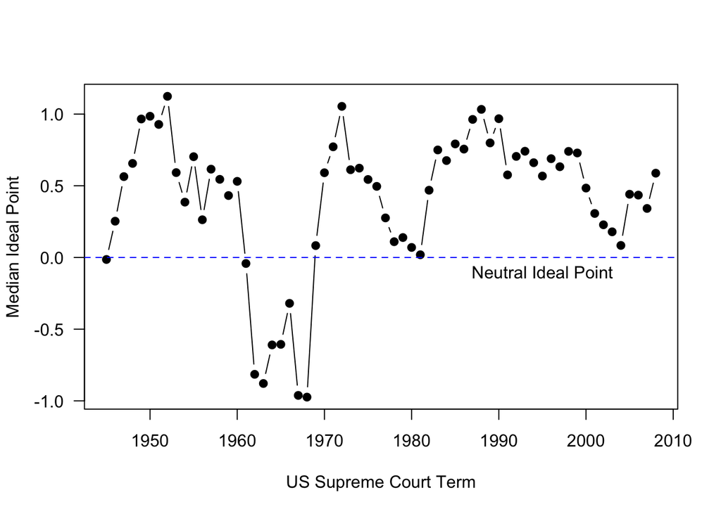

## Question 2 (20 points)

Next, we would like to identify the name of the justice with an ideal position equal to the median ideal point **for each term**. Use a for loop to do so!

The loop should: (14 points)

- go though each term
- identify the justice whose ideal position is equal to the the median position in this term
- save the names of the justices for each term in a container object called `median_justice`.

In addition, answer in the text the following questions. [Instead of copy-pasting numbers in your answer, please use ‘r some code’. For example, if you want to refer to the mean value of the ideal positions of all justices, instead of writing, the mean ideal position is ” -0.008321182”, write the mean ideal position is -0.0083212, see how this looks in Rmarkdown.]

1. Which justice had the median ideal point in the most terms? (3 points)
2. How long did this justice serve on the Court overall? (2 points)
3. What was this justice’s average ideal point over his/her entire tenure on the Court? (1 points)

## Answer 2

**Median justices by term**

```
##          1945          1946          1947          1948          1949
##        "Reed"        "Reed"        "Reed" "Frankfurter"      "Burton"
##          1950          1951          1952          1953          1954
##      "Burton"      "Burton"       "Clark"       "Clark" "Frankfurter"
##          1955          1956          1957          1958          1959
## "Frankfurter"       "Clark"       "Clark"       "Clark"       "Clark"
##          1960          1961          1962          1963          1964
##     "Stewart"       "White"    "Goldberg"     "Brennan"    "Goldberg"
##          1965          1966          1967          1968          1969
##       "Black"       "Black"    "Marshall"    "Marshall"       "Black"
##          1970          1971          1972          1973          1974
##      "Harlan"       "White"       "White"       "White"       "White"
##          1975          1976          1977          1978          1979
##     "Stewart"     "Stewart"    "Blackmun"    "Blackmun"       "White"
##          1980          1981          1982          1983          1984
##       "White"       "White"       "White"       "White"      "Powell"
##          1985          1986          1987          1988          1989
##      "Powell"      "Powell"       "White"       "White"       "White"
##          1990          1991          1992          1993          1994
##      "Souter"      "Souter"    "O'Connor"     "Kennedy"    "O'Connor"
##          1995          1996          1997          1998          1999
##     "Kennedy"     "Kennedy"     "Kennedy"     "Kennedy"    "O'Connor"
##          2000          2001          2002          2003          2004
##    "O'Connor"    "O'Connor"    "O'Connor"    "O'Connor"    "O'Connor"
##          2005          2006          2007          2008
##     "Kennedy"     "Kennedy"     "Kennedy"     "Kennedy"
```

**Number of times a given justice had a position equal to the median term position**

```
## median_justice
##       Black    Blackmun     Brennan      Burton       Clark Frankfurter
##           3           2           1           3           6           3
##    Goldberg      Harlan     Kennedy    Marshall    O'Connor      Powell
##           2           1           9           2           8           3
##        Reed      Souter     Stewart       White
##           3           2           3          13
```

**How long did this justice serve on the Court overall?**

```
## [1] 32
```

**What was this justice’s average ideal point over his/her entire tenure on the Court?**

```
## [1] 0.4401563
```

## Question 3 (30 points)

We now turn to the relationship between Supreme Court ideology and the president. Specifically, we want to see how the ideology of the Supreme Court changes over the course of each president’s time in office.

- Begin by creating two empty ‘container’ vectors: one to hold Democratic presidents (name it `dem_pres_shift`), and another for Republican presidents( (name it `rep_pres_shift`). Label each vector with the presidents’ names. (6 points)
- Next, using a loop, calculate for each Democratic president the shift in Supreme Court ideology by subtracting the Court’s median ideal point in the president’s first term from its median ideal point in the president’s last term. (10 points)
- Store these values in your Democratic container vector (`dem_pres_shift`). (2 points)
- Repeat the same process for Republican presidents. (Hint: you can create a second loop.) (12 points)

## Answer 3

**Empty container `dem_pres_shift`**

```
##  Truman Kennedy Johnson  Carter Clinton
##      NA      NA      NA      NA      NA
```

**Empty container `rep_pres_shift`**

```
## Eisenhower      Nixon       Ford     Reagan BushSenior BushJunior
##         NA         NA         NA         NA         NA         NA
```

**Ideological change in the Supreme Court during Democratic presidents**

```
##  Truman Kennedy Johnson  Carter Clinton
##   1.138  -0.837  -0.364  -0.206  -0.257
```

**Ideological change in the Supreme Court during Republican presidents**

```
##  Eisenhower       Nixon        Ford      Reagan  BushSenior  BushJunior
## -0.06099999  0.54000003 -0.04800004  1.01399999 -0.09400004  0.28099999
```

## Question 4 (10 points)

- What was the mean and standard deviation of the Supreme Court ideology shifts you just calculated when looking only at the Democratic presidencies?
- What about the Republican presidencies?
- Which Republican president’s tenure had the largest conservative (positive) shift on the Court?
- Which Democratic president’s tenure had the largest liberal (negative) shift?

## Answer 4

**Mean and standard deviation of the Supreme Court ideology shifts (Democratic presidencies)**

```
## [1] -0.1052
```

```
## [1] 0.7384542
```

**Mean and standard deviation of the Supreme Court ideology shifts (Republican presidencies)**

```
## [1] 0.272
```

```
## [1] 0.4403894
```

```
## Kennedy
##  -0.837
```

```
## Reagan
##  1.014
```

## Question 5 (30 points)

In this task you will create a plot which shows the median Supreme Court ideal point over time together with the ideological development of each justice over time.

A similar plot was recently features in the Economist after the death of Ruth Bader Ginsburg in 2020. Those interested in the article can read it here: https://www.economist.com/graphic-detail/2020/09/21/the-supreme-court-may-be-about-to-take-a-hard-right-turn . CEU’s library has a free access to articles from `The Economist`.

Do the following steps:

- Create a plot that shows the median Supreme Court ideal point over time. Use a thick black line (thickness equal to 4). (3 points) [The figure below uses transparency level equal to 0.7]
- Then, add lines for the ideal points of each unique justice to the same plot. Use a `for loop` for this purpose. (10 points)
- The color of each line should be `orangered` if the justice was appointed by a Republican and `steelblue4` if he or she was appointed by a Democrat. (You can assume that when a Justice first appears in the data, they were appointed by the president sitting during that term.) (10 points)
- Label each line with the justice’s last name. (5 points)
- Briefly discuss what trends in the ideology of justices you see over time. (2 points)

## Answer 5

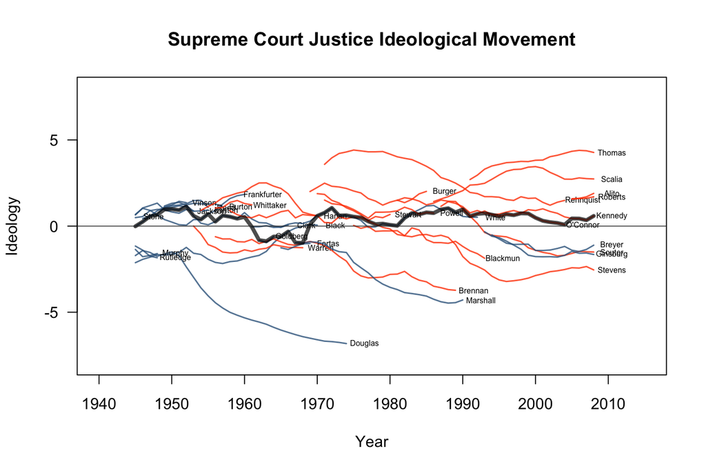

## Question 6 (Bonus question for 20 points)

Your boss really likes the graph you created in question 5, great job! She thinks that the graph can be tailored a bit. In, particular, she asks you to do the following changes:

1. Make the ideal points lines of the last justices - those who were still justices between 2000 and 2008 - thicker. (5 points)
2. Add a point for the starting ideological point of each justice. Make these points for the last justices bigger than for the remaining justices. (5 points)
3. Make the names of the last justices readable (change their positions, so that the names do not overlap) and color them according to the party color of the president that appointed these justices. (5 points)
4. Include the following information: (5 points)
- Label the conservative and liberal side of the ideological spectrum using arrows
- Add a label for the median justice line.
- Add a legend for the colors of the justices ideal points. Make the same legend as in the example below. Notice that this legend has no box, the legend points are horizontal and there is a title.

Hints:

- To specify which justices’ should have thicker lines and bigger points, you can use different conditional statements within the loop (e.g. `if(){}, if(){}else{}` etc.).
- If you would like to find out which justices were justices between 2000 and 2008 you can use the value matching `%in%` operator. This operator allows you to compare which elements in a given vector (e.g. vector x) occur in another vector (e.g. vector y). For example, let’s say you have a vector x with the numbers `c(1,3,2,5,4)` and another vector y with the numbers `c(3,4,6)`. You would like to know which elements in x have a match in y. To do so you can run `x %in% y` and R will return a vector with TRUE and FALSE for each element in x. TRUE indicates that a given element in x had a match in y.

```r
x <- c(1,3,2,5,4)
y <- c(3,4,6)

res_match <- x %in% y
res_match
```

```
## [1] FALSE  TRUE FALSE FALSE  TRUE
```

```r
# You can count how many elements were matched by using `sum(res_match)`
sum(res_match)
```

```
## [1] 2
```

- remember that you can adjust the colors to be transparent by applying the function `adjustcolor("colorname", number_for_transparency_level)`. The graph below uses most of the time `adjustcolor("orangered", 0.8)` and `adjustcolor("steelblue4", 0.8)`
- you can draw arrows using the function `arrows()`, where you need to specify the coordinates of the arrow using the arguments `x0`, `y0` (starting point of the arrow on the x and y coordinates respectively), `x1`, `y1` (end point of the arrow on the x and y coordinates respectively). Additionally, the following arguments were specified in the `arrows()` function used in the below plot: `length = 0.05`, `angle = 30`, `code = 2`, `col = steelblue4`.
- To learn more how to draw a legend with specific features, type `?legend` in the console. The R documentation provides detailed information on many features that can be specified in the legend. For example, you find information about the type of the box to be drawn around the legend (argument `bty`), whether to set the legend horizontal or vertical (argument `horiz`), the color, adjustment and the text of the title within the legend (arguments `title.col`, `title.adj`, `title`)

## Answer 6

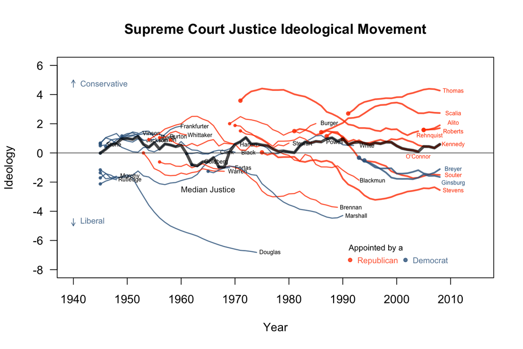

## Evaluation

- 5 questions for a total of 100 points
- 1 bonus question for a total of 20 points